# Patriotism

2018-07-03

> I take a lot of liberties with my understanding of history here. I’m sure people with a better grasp of history could find a hundred things wrong with this post.

I’m progressive. I’m a social democrat. I’m a leftist. A lot of my friends are like me. Many of those friends are hesitant or embarrassed to call themselves patriotic. Admittedly it is a bit contrived to take personal pride in something you were likely born with, fortunate enough for it to be in a certain area between two artificial lines a few warring white guys came up with years before you were here.

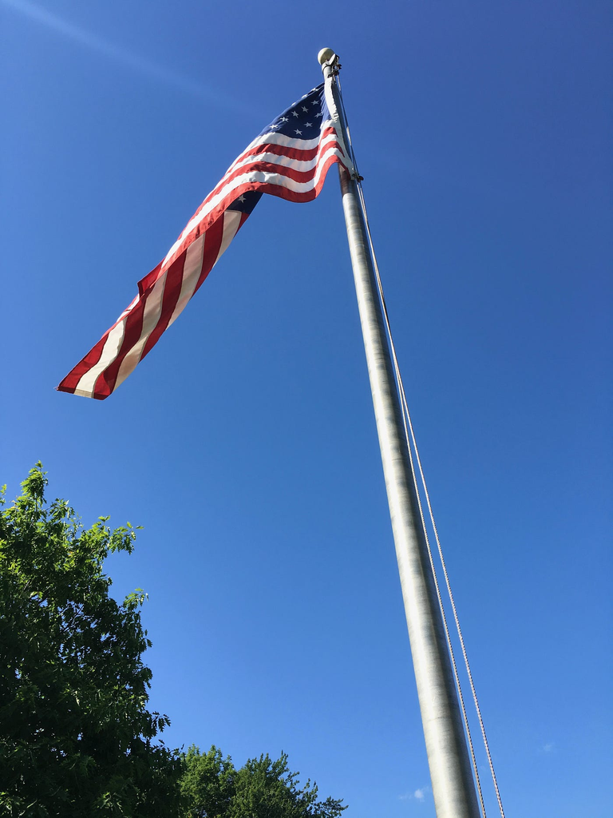

Flag outside of Harrison Lyseth Elementary School in Portland, ME

When I think of patriotism, I think about the so-called “greatest generation.” Our grandparents who came back from World War II were rightly proud of America. They weren’t perfect (far from it — just ask any people of color), but to them that pride was an impetus to make their country a better place for everyone. Pride in our common public good and pride in our nation were the same thing.

That definition of patriotism has slipped away. A romanticized caricature of “rugged individualism” nudged it out of the way. Government was swallowed whole by cynicism — it went from being about ourselves and our values to being a incompetent adversary. Our flag and anthems were repossessed by jingoists and xenophobes.

I like to reframe what it means to be patriotic. I like to think of that greatest generation, and what they built when they came home from a world that was burning down. I want to take patriotism back.

It’s patriotic to have a top-notch education system that creates the most intelligent society the world has ever known.

It’s patriotic to have shining cities with clean, efficient, free public transit.

It’s patriotic to take care of the weakest among us because our country is so damned great we never let one of our own suffer because they can’t pay for it.

It’s patriotic to have a space program that brings our species places they’ve never been and is the envy of the world.

It’s patriotic to have the cleanest air and water in the world.

It’s patriotic to rely on no one else’s resources to provide us with energy when we can get it from our own renewable resources.

It’s patriotic to have a military force that helps nations who need us when they’ve had an environmental or a real humanitarian disaster.

It’s patriotic to welcome anyone in the world who needs our protection, especially (but not necessarily) if they want to pitch in and help build up this country in whatever way they’re able.

It’s patriotic to share our riches because we have so much.

All of these things are possible. We live in the wealthiest society the world has ever known. It’s patriotic to try to make it a reality, and there’s nothing wrong with having some pride in what you’ve built for your neighbors. Being cynical about our public good, and fighting tooth and nail to decimate it, is the opposite of patriotism.

Happy 4th of July.

[This work is licensed under a [Creative Commons Attribution-NonCommercial-NoDerivatives 4.0 International License](http://creativecommons.org/licenses/by-nc-nd/4.0/) .](http://creativecommons.org/licenses/by-nc-nd/4.0/)